# **Introducción a la asignatura Análisis de datos: principales herramientas**

Julio Sanmartino Rodríguez

UCM - NextIBS

julioasa@ucm.es - julio.sanmartino@nextibs.com

## 1. ¿Qué es el Big Data?

[figure not shown]

Según la definición de Gartner (2001) el Big Data son activos de información de gran volumen, alta velocidad y/o gran variedad, que exigen formas rentables e innovadoras de procesamiento de información que permitan una mejor comprensión, toma de decisiones y automatización de procesos. Es por ésto que comunmente se asocia el Big Data a tres uves: volumen, velocidad y variedad.

Os comparto un par de videos que pueden ser de vuestro interés:

- [Big data is better data](https://www.ted.com/talks/kenneth_cukier_big_data_is_better_data?utm_campaign=tedspread&utm_medium=referral&utm_source=tedcomshare)
- [Big Data & AI for Bad Guys](https://www.youtube.com/embed/PfM6xXkB78M)

### 1.1. ¿Cuáles son las habilidades básicas para trabajar en el ámbito del Big Data?

Los dos pilares principales que sustentan el Big Data son una parte técnica (basada en conocimientos de matemáticas, estadística, informática, programación y bases de datos) y otra parte de negocios (orientada al conocimiento de las necesidades de las empresas para la aplicación de lo anterior).

Algunas de las competencias básicas del Big Data que trabajaremos durante la asignatura son:

- Conocer lenguajes y/o herramientas de programación estadística (R).
- Mejorar la competencia matemática en los ámbitos del álgebra lineal (vectores, matrices, etc.), cálculo (operaciones matemáticas) y probabilidad.
- Comprender las diferencias entre estadística descriptiva e inferencial.
- Limpiar y transformar datos (data cleaning y/o data wrangling).

### 1.2. ¿Por qué Big Data?

Según el Foro Económico Mundial, de los 10 trabajos que más crecerán en el mundo durante el periodo 2018-2022, tres están directamente vinculados con el ámbito del Big Data:

- Analista de datos
- Inteligencia artificial y machine learning
- Especialista en Big Data

Y otros cuatro, relacionados con las posibilidades que ofrece este campo:

- Profesional de ventas y márketing
- Especialista en transformación digital
- Especialista en nuevas tecnologías
- Especialista en TIC

### 1.3. ¿Mi perfil es Big Data?

[figure not shown]

## 2. Objetivos de la asignatura

**Objetivo general**:  
Hacer uso de las posibilidades que ofrece la estadística, mediante el software de código abierto R, en el ámbito del análisis descriptivo de los datos.

**Objetivos específicos**:  
- Identificar los principales conceptos y fundamentos de la estadística descriptiva e inferencial.  
- Descubrir el lenguaje y entorno de programación R.  
- Testear las principales técnicas estadísticas para el análisis descriptivo de datos en el ámbito empresarial, de investigación, desarrollo e innovación.  
- Desarrollar actitudes colaborativas, de debate y de trabajo en equipos multidisciplinares y multiculturales.

## 3. ¿Qué es R?

[The R Project for Statistical Computing](https://www.r-project.org/) o R, es un lenguaje de programación y entorno orientado a objetos, para el análisis estadístico y gráfico. Está disponible como software libre bajo los términos de la Licencia pública general GNU de la Free Software Foundation en forma de código fuente. Compila y se ejecuta en una amplia variedad de plataformas UNIX y sistemas similares (incluidos FreeBSD y Linux), Windows y MacOS. Creado en sus inicios por John Chambers en los Laboratoiros Bell (AT&T, ahora Lucent Technologies), ahora es el resultado de la colaboración de una gran comunidad de usuarios.

### 3.1. ¿Por qué R?

[figure not shown]

R es una suite o paquete informático que incluye:

- Un entorno efectivo para el manejo y el almacenamiento de datos.
- Un conjunto de operadores para cálculos en distintos tipos de objetos, en especial matrices (ej. tablas).
- Una colección grande, coherente e integrada de herramientas para el análisis de datos.
- Facilidades gráficas para el análisis y visualización de datos.
- Un lenguaje de programación bien desarrollado, simple y efectivo.

Además, es gratis y ampliamente extensible y está siempre actualizado con funciones y paquetes/librerías desde el repositorio oficial [Comprehensive R Archive Network (CRAN)](https://cran.r-project.org/mirrors.html) y permite producir trazados bien diseñados con calidad de publicación, incluyendo su propio formato de documentación similar a LaTeX.

[figure not shown]

### 3.2. Librerías o paquetes de R

Una librería o paquete de R es un conjunto de funciones, datos y documentación que facilitan el manejo de la herramienta. R-base tiene cargados algunos paquetes por defecto y con ellos se pueden hacer análisis estadísticos completos. Podemos ver sus nombres mediante la función *loadedNamespaces()*. Sin embargo, el éxito de R es la gran variedad y constante actualización[^1] de paquetes que extienden los métodos y capacidades de la herramienta. Como ya hemos comentado, están disponibles a través del repositorio oficial de paquetes de R.

En definitiva, R es una de las herramientas más utilizadas en el ámbito del análisis de datos a nivel empresarial (Google, Facebook, Twitter, Microsoft, IBM, Uber, Airbnb, etc.)[^2] debido a la gran cantidad de técnicas estadísticas, opciones de cálculo, de manipulación de datos y de visualización gráfica que incluye. Os adjunto algunas lecturas interesantes que pueden resultar de vuestro interés sobre la herramienta:

- Why R is the best data science language to learn today
- [Why i use R for data science-An ode to R](https://www.shirin-glander.de/2017/09/ode_to_r/)
- [6 reasons to learn R for business](https://www.business-science.io/business/2017/12/27/six-reasons-to-use-R-for-business.html)

### 3.3. Descarga e instalación de R-base

Para empezar, vamos a descargar R-base desde su [página web](https://cran.rediris.es/). La última versión disponibles es la 4.1.1 (octubre de 2021):

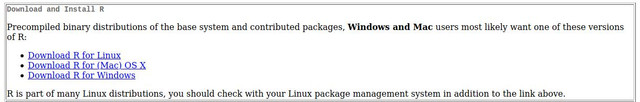

Elegimos la versión que se ajuste a nuestro sistema operativo y la instalamos. Si ejecutais el programa R base veréis que se trata de una interfaz gráfica muy simple. Viene a ser una copia de la terminal de Linux:

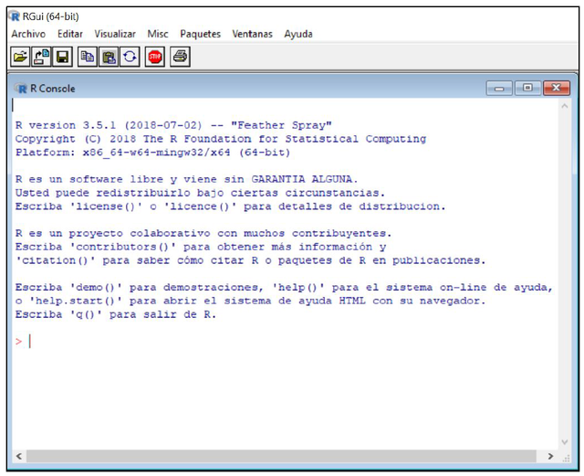

Se puede trabajar perfectamente con ella, sin embargo, existe un entorno de desarrollo integrado (IDE) para R denominado RStudio.

## 4. RStudio

RStudio es un entorno de desarrollo integrado para R que mejora la interfaz de usuario (GUI, Graphical User Interface). Incluye la consola de R, un editor de resaltado de sintaxis que admite la ejecución directa de código, así como herramientas para el trazado, el historial, la depuración y la gestión del espacio de trabajo. RStudio permite trabajar con R de forma más sencilla. Descargaremos RStudio en su versión de escritorio (desktop) de su [página web](https://rstudio.com/products/rstudio/).

Una vez instalado, siempre trabajaremos con RStudio porque, entre otras cosas:

- Respeta la filosofía tradicional de la consola de R.
- Muestra los objetos creados.
- Muestra el historial de comandos.
- Tiene un visor de gráficos que unifica entornos de trabajo.
- Integra la lista de paquetes instalados y/o cargados (Library).
- Contiene un menú de Ayuda.
- Permite ejecutar trozos de código con sólo marcarlo en los scripts.
- Dispone de autocompletado de código.
- Permite exportar informes en .pdf, .html (HTML5) y de texto y hacer presentaciones.
- Facilidad para trabajar con varios proyectos a la vez.

En el campus virtual tenéis una guía sobre la apariencia y los distintos menús y opciones que ofrece RStudio pero, resumiendo, se compone de cuatro ventanas con las que trabajeremos a partir de ahora:

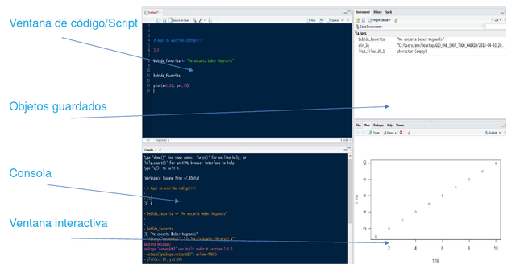

La ventana de **Código/Script**, donde trabajaremos de forma habitual. La de **Objetos Guardados**, donde se van almacenando los objetos, funciones y variables creadas en cada ambiente, además del historial de comandos. La ventana de la **Consola**, que permite ejecutar código y observar resultados y, por último, la ventana **Interactiva**, que permite explorar archivos, visualizar gráficos, gestionar paquetes, ver la ayuda, etc.

### 4.1. RMarkdown

[RMarkdown](https://rmarkdown.rstudio.com/) proporciona un marco de creación para la ciencia de datos. Un solo archivo RMarkdown permite guardar y ejecutar código y generar informes de alta calidad, completamente reproducibles y que admiten múltiples de formatos de salida estáticos y dinámicos, como HTML, PDF, y MS Word. El siguiente video explica brevemente las posibilidades que ofrece RMarkdown.

[video not shown]

#### 4.1.1. Instalación

Como el resto de R, RMarkdown es gratuito y de código abierto y se instala mediante el paquete “rmarkdown” del CRAN (Comprehensive R Archive Network).

```r
#install.packages("rmarkdown")
```

#### 4.1.2. ¿Cómo funciona?

Este es un ejemplo de archivo RMarkdown, un archivo de texto sin formato que tiene la extensión .Rmd:

[figure not shown]

El archivo contiene tres tipos de contenido:

- Un encabezado YAML [^3] (opcional)
- Fragmentos de código (chunks) R
- Texto mezclado con formato de texto simple

Cuando abrimos un archivo .Rmd en el IDE de RStudio, se convierte en una interfaz de bloc de notas para R, donde se puede ejecutar cada fragmento de código haciendo clic en el icono de la derecha (play). RStudio ejecuta el código y muestra los resultados en línea con su archivo:

[figure not shown]

Para generar un informe a partir del archivo, usaremos el botón *“Knit”* para renderizar el archivo y obtener una vista previa de la salida con un solo clic. RMarkdown genera un nuevo archivo que contiene texto, código y resultados seleccionados del archivo .Rmd. El nuevo archivo puede ser una página web terminada, PDF o documento de MS Word, entre otros.

Podéis encontrar una guía rápida de utilización, la [R Markdown Cheatsheet](https://rstudio.com/resources/cheatsheets/) en el [Campus virtual de Next Educación](https://campusvirtual.nexteducacion.com/), así como un archivo .pdf sobre la generación de informes, como éste, con RStudio y Rmarkdown.

[^1]: Se puede seguir a la comunidad R a través de r-bloggers.com, en Twitter (@Rbloggers) o a través de rweekly.org.
[^2]: The Enterprise Applications of the [R Language Conference (EARL)](http://earlconf.com).
[^3]: Formato de serialización de datos amigable para el ser humano y estándar para todos los lenguajes de programación.